# PROPOSAL:

## Thành viên:

### 1. Đào Thị Cẩm Tiên - 19133055

### 2. Nguyễn Anh Đắc - 19133020

### 3. Nguyễn Thanh Tân Kỷ - 19133031

## Đề tài: Life Expectancy (WHO)

## Phần 1:

- Dữ liệu đến từ Kaggle và thu thập được qua link:

  https://www.kaggle.com/kumarajarshi/life-expectancy-who?fbclid=IwAR3UbdRxFiIt_osMmuXPkADj2sXNiRLrjag8vrEcv4RlclHB77jyEHAYuVQ
- Các trường hợp xảy ra:
  - Tỷ lệ tử vong của Trẻ sơ sinh và Người lớn ảnh hưởng đến tuổi thọ như thế nào?
  - Một quốc gia có giá trị tuổi thọ thấp hơn (<65) có nên tăng chi tiêu cho chăm sóc sức khỏe để cải thiện tuổi thọ trung bình của mình không?
  - Các quốc gia đông dân có xu hướng có tuổi thọ thấp hơn không?
  - Chúng ta có nên tăng chỉ số phát triển con người ở các nước đã và đang phát triển để cải thiện tuổi thọ trung bình hay không?
  - So sánh các ca bệnh sởi giữa các nước đang phát triển và các nước đã phát triển. Từ đó hãy cho thấy ảnh hưởng của nó đối với tuổi thọ của các nước đó.
- Các biến phân loại: Country, Year, Status.
- Các biến số: Life expectancy, Adult Mortality, infant deaths, Alcohol, percentage expenditure, Hepatitis B, Measles, BMI, under-five deaths, Polio, Total expenditure, Diphtheria, HIV/AIDS, GDP, Population, thinness 1-19 years, thinness 5-9 years, Income composition of resources, Schooling.

### Ý nghĩa của các biến có trong dataset:

- Country: Đất nước
- Year: năm
- Status: tình trạng đang phát triển hay phát triển
- Life expectancy: Kỳ vọng tuổi thọ (age)
- Adult Mortality: Tỷ lệ tử vong ở người trưởng thành15-60 tuổi ( trên 1000 dân số))
- infant deaths: Số trẻ sơ sinh tử vong ( trên 1000 dân số)
- Alcohol: rượu tiêu thụ bình quân đầu người (>15 age) (tính bằng lít rượu nguyên chất)
- percentage expenditure: Chi cho y tế tính theo phần trăm Tổng sản phẩm quốc nội trên đầu người (%)
- Hepatitis B: Tỷ lệ tiêm chủng Viêm gan B (HepB) ở trẻ 1 tuổi (%)
- Measles: bệnh sở - số ca được báo cáo (trên 1000 dân số)
- BMI: Chỉ số khối cơ thể
- under-five deaths: Số người chết dưới 5 tuổi (trên 1000 dân))
- Polio: Bại liệt ở trẻ 1 tuổi (%)
- Total expenditure: Chi tiêu chung của chính phủ cho y tế tính theo tỷ lệ phần trăm của tổng chi tiêu của chính phủ (%)
- Diphtheria: Tỷ lệ tiêm chủng giải độc tố uốn ván và ho gà (DTP3) cho trẻ 1 tuổi (%)
- HIV/AIDS: Tử vong trên 1000 trẻ sinh sống HIV / AIDS (0-4 tuổi)
- GDP: Tổng sản phẩm quốc nội bình quân đầu người (tính bằng USD)
- Population: Dân số
- thinness 1-19 years:Tỷ lệ gầy ở trẻ em và thanh thiếu niên từ 10 đến 19 tuổi (%)
- thinness 5-9 years: Tỷ lệ gầy ở trẻ em từ 5-9 tuổi (%)
- Income composition of resources:Chỉ số phát triển con người về cơ cấu thu nhập của tài nguyên (chỉ số từ 0 đến 1)
- Schooling: Số năm đi học (năm)

## Phần 2:

```python
import pandas as pd
Data = pd.read_csv('Life Expectancy Data.csv')
# 3 dòng đầu tiên:
Data.head(3)
```

|  | Country | Year | Status | Life expectancy | Adult Mortality | infant deaths | Alcohol | percentage expenditure | Hepatitis B | Measles | ... | Polio | Total expenditure | Diphtheria | HIV/AIDS | GDP | Population | thinness 1-19 years | thinness 5-9 years | Income composition of resources | Schooling |
| --- | --- | --- | --- | --- | --- | --- | --- | --- | --- | --- | --- | --- | --- | --- | --- | --- | --- | --- | --- | --- | --- |
| 0 | Afghanistan | 2015 | Developing | 65.0 | 263.0 | 62 | 0.01 | 71.279624 | 65.0 | 1154 | ... | 6.0 | 8.16 | 65.0 | 0.1 | 584.259210 | 33736494.0 | 17.2 | 17.3 | 0.479 | 10.1 |
| 1 | Afghanistan | 2014 | Developing | 59.9 | 271.0 | 64 | 0.01 | 73.523582 | 62.0 | 492 | ... | 58.0 | 8.18 | 62.0 | 0.1 | 612.696514 | 327582.0 | 17.5 | 17.5 | 0.476 | 10.0 |
| 2 | Afghanistan | 2013 | Developing | 59.9 | 268.0 | 66 | 0.01 | 73.219243 | 64.0 | 430 | ... | 62.0 | 8.13 | 64.0 | 0.1 | 631.744976 | 31731688.0 | 17.7 | 17.7 | 0.470 | 9.9 |

3 rows × 22 columns

```python
# 3 dòng cuối:
Data.tail(3)
```

|  | Country | Year | Status | Life expectancy | Adult Mortality | infant deaths | Alcohol | percentage expenditure | Hepatitis B | Measles | ... | Polio | Total expenditure | Diphtheria | HIV/AIDS | GDP | Population | thinness 1-19 years | thinness 5-9 years | Income composition of resources | Schooling |
| --- | --- | --- | --- | --- | --- | --- | --- | --- | --- | --- | --- | --- | --- | --- | --- | --- | --- | --- | --- | --- | --- |
| 2935 | Zimbabwe | 2002 | Developing | 44.8 | 73.0 | 25 | 4.43 | 0.0 | 73.0 | 304 | ... | 73.0 | 6.53 | 71.0 | 39.8 | 57.348340 | 125525.0 | 1.2 | 1.3 | 0.427 | 10.0 |
| 2936 | Zimbabwe | 2001 | Developing | 45.3 | 686.0 | 25 | 1.72 | 0.0 | 76.0 | 529 | ... | 76.0 | 6.16 | 75.0 | 42.1 | 548.587312 | 12366165.0 | 1.6 | 1.7 | 0.427 | 9.8 |
| 2937 | Zimbabwe | 2000 | Developing | 46.0 | 665.0 | 24 | 1.68 | 0.0 | 79.0 | 1483 | ... | 78.0 | 7.10 | 78.0 | 43.5 | 547.358878 | 12222251.0 | 11.0 | 11.2 | 0.434 | 9.8 |

3 rows × 22 columns

```python
Data.shape
```

```
(2938, 22)
```

```python
Data.describe()
```

|  | Year | Life expectancy | Adult Mortality | infant deaths | Alcohol | percentage expenditure | Hepatitis B | Measles | BMI | under-five deaths | Polio | Total expenditure | Diphtheria | HIV/AIDS | GDP | Population | thinness 1-19 years | thinness 5-9 years | Income composition of resources | Schooling |
| --- | --- | --- | --- | --- | --- | --- | --- | --- | --- | --- | --- | --- | --- | --- | --- | --- | --- | --- | --- | --- |
| count | 2938.000000 | 2928.000000 | 2928.000000 | 2938.000000 | 2744.000000 | 2938.000000 | 2385.000000 | 2938.000000 | 2904.000000 | 2938.000000 | 2919.000000 | 2712.00000 | 2919.000000 | 2938.000000 | 2490.000000 | 2.286000e+03 | 2904.000000 | 2904.000000 | 2771.000000 | 2775.000000 |
| mean | 2007.518720 | 69.224932 | 164.796448 | 30.303948 | 4.602861 | 738.251295 | 80.940461 | 2419.592240 | 38.321247 | 42.035739 | 82.550188 | 5.93819 | 82.324084 | 1.742103 | 7483.158469 | 1.275338e+07 | 4.839704 | 4.870317 | 0.627551 | 11.992793 |
| std | 4.613841 | 9.523867 | 124.292079 | 117.926501 | 4.052413 | 1987.914858 | 25.070016 | 11467.272489 | 20.044034 | 160.445548 | 23.428046 | 2.49832 | 23.716912 | 5.077785 | 14270.169342 | 6.101210e+07 | 4.420195 | 4.508882 | 0.210904 | 3.358920 |
| min | 2000.000000 | 36.300000 | 1.000000 | 0.000000 | 0.010000 | 0.000000 | 1.000000 | 0.000000 | 1.000000 | 0.000000 | 3.000000 | 0.37000 | 2.000000 | 0.100000 | 1.681350 | 3.400000e+01 | 0.100000 | 0.100000 | 0.000000 | 0.000000 |
| 25% | 2004.000000 | 63.100000 | 74.000000 | 0.000000 | 0.877500 | 4.685343 | 77.000000 | 0.000000 | 19.300000 | 0.000000 | 78.000000 | 4.26000 | 78.000000 | 0.100000 | 463.935626 | 1.957932e+05 | 1.600000 | 1.500000 | 0.493000 | 10.100000 |
| 50% | 2008.000000 | 72.100000 | 144.000000 | 3.000000 | 3.755000 | 64.912906 | 92.000000 | 17.000000 | 43.500000 | 4.000000 | 93.000000 | 5.75500 | 93.000000 | 0.100000 | 1766.947595 | 1.386542e+06 | 3.300000 | 3.300000 | 0.677000 | 12.300000 |
| 75% | 2012.000000 | 75.700000 | 228.000000 | 22.000000 | 7.702500 | 441.534144 | 97.000000 | 360.250000 | 56.200000 | 28.000000 | 97.000000 | 7.49250 | 97.000000 | 0.800000 | 5910.806335 | 7.420359e+06 | 7.200000 | 7.200000 | 0.779000 | 14.300000 |
| max | 2015.000000 | 89.000000 | 723.000000 | 1800.000000 | 17.870000 | 19479.911610 | 99.000000 | 212183.000000 | 87.300000 | 2500.000000 | 99.000000 | 17.60000 | 99.000000 | 50.600000 | 119172.741800 | 1.293859e+09 | 27.700000 | 28.600000 | 0.948000 | 20.700000 |

```python
Data.info()
```

```
<class 'pandas.core.frame.DataFrame'>
RangeIndex: 2938 entries, 0 to 2937
Data columns (total 22 columns):
 #   Column                           Non-Null Count  Dtype
---  ------                           --------------  -----
 0   Country                          2938 non-null   object
 1   Year                             2938 non-null   int64
 2   Status                           2938 non-null   object
 3   Life expectancy                  2928 non-null   float64
 4   Adult Mortality                  2928 non-null   float64
 5   infant deaths                    2938 non-null   int64
 6   Alcohol                          2744 non-null   float64
 7   percentage expenditure           2938 non-null   float64
 8   Hepatitis B                      2385 non-null   float64
 9   Measles                          2938 non-null   int64
 10   BMI                             2904 non-null   float64
 11  under-five deaths                2938 non-null   int64
 12  Polio                            2919 non-null   float64
 13  Total expenditure                2712 non-null   float64
 14  Diphtheria                       2919 non-null   float64
 15   HIV/AIDS                        2938 non-null   float64
 16  GDP                              2490 non-null   float64
 17  Population                       2286 non-null   float64
 18   thinness  1-19 years            2904 non-null   float64
 19   thinness 5-9 years              2904 non-null   float64
 20  Income composition of resources  2771 non-null   float64
 21  Schooling                        2775 non-null   float64
dtypes: float64(16), int64(4), object(2)
memory usage: 505.1+ KB
```

## Phần 3:

- Các nhóm so sánh: Kỳ vọng về cuộc sống của các nhóm nước "đang phát triển" và các nhóm nước "đã phát triển".
- Phân tích dữ liệu sơ bộ, bao gồm một số thống kê tóm tắt và biểu đồ trực quan hóa, cùng với một số giải thích về cách chúng giúp nhóm hiểu thêm về tập dữ liệu.

```python
Data.columns=['Country', 'Year', 'Status', 'Life_expectancy', 'Adult_Mortality',
       'infant_deaths', 'Alcohol', 'percentage_expenditure', 'Hepatitis_B',
       'Measles', 'BMI', 'under_five_deaths', 'Polio', 'Total_expenditure',
       'Diphtheria', 'HIV/AIDS', 'GDP', 'Population',
       'thinness', 'thinness_5-9_years',
       'Income_composition_of_resources', 'Schooling']
```

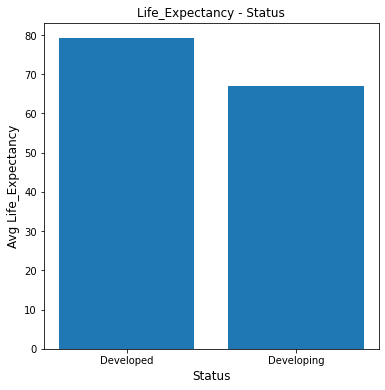

```python
import seaborn as sns
import matplotlib.pyplot as plt
plt.figure(figsize=(6,6))
plt.bar(Data.groupby('Status')['Status'].count().index,Data.groupby('Status')['Life_expectancy'].mean())
plt.xlabel("Status",fontsize=12)
plt.ylabel("Avg Life_Expectancy",fontsize=12)
plt.title("Life_Expectancy - Status")
plt.show()
```

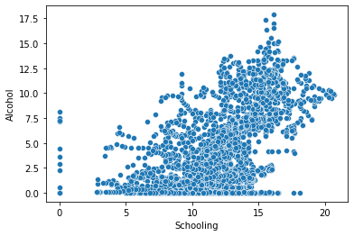

```python
sns.scatterplot(x=Data['Schooling'],y=Data['Alcohol'])
```

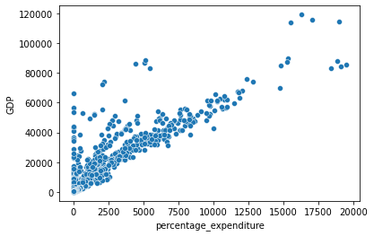

```python
sns.scatterplot(x=Data['percentage_expenditure'],y=Data['GDP']);
```

- Kết quả từ các phương pháp thống kê cụ thể này là cần thiết để hỗ trợ cho giả thuyết của nhóm
  - Thống kê so sánh: so sánh các tác động bên ngoài có ảnh hưởng đến tuổi thọ giữa các nước đang phát triển và đã phát triển.
  - Thống kê mô tả: cho ra được các biểu đồ trực quan của từng biến trong bộ dữ liệu.
  - Thống kê tìm kiếm mối liên quan: cho ra được biểu đồ mối quan hệ giữa 2 biến.